# 1. Conjugate baseline: how satisfied are customers, before any covariates?

Airline Customer Satisfaction – Bayesian Learning project

## 0. Data

Builds directly on `00_data_audit_eda_subsampling.Rmd`: we read `data/train_subsample.csv`, the same stratified n ~= 1200 training split that every later section (JAGS, BAS, prediction) reuses unchanged.

```r
train <- read.csv("data/train_subsample.csv", stringsAsFactors = FALSE)
train$cabin_class <- factor(train$cabin_class, levels = c("Eco", "Eco Plus", "Business"))

n <- nrow(train)
x <- sum(train$satisfaction == "satisfied")

cat("n =", n, " | satisfied =", x, " | raw proportion =", round(x / n, 4), "\n")
```

```
## n = 1197  | satisfied = 656  | raw proportion = 0.548
```

## 1. Model

Each customer $i$ is treated as an independent trial, $X_i \mid p \sim \text{Bernoulli}(p)$, where $p$ is the (unknown) true satisfaction rate in the customer population. Aggregating over the $n$ customers, the total number satisfied, $X = \sum_i X_i$, follows

$$X \mid p \sim \text{Binomial}(n, p),
\qquad p \sim \mathscr{B}e(\alpha_0, \beta_0)$$

Since the Beta distribution is conjugate to the Binomial likelihood, the posterior is available in closed form – no sampler needed:

$$p \mid X \sim \mathscr{B}e(\alpha_0 +
X,\ \beta_0 + n - X)$$

```r
mean.beta <- function(a, b) a / (a + b)

var.beta <- function(a, b) (a * b) / ((a + b)^2 * (a + b + 1))

mode.beta <- function(a, b) {
  ifelse(a > 1 & b > 1, (a - 1) / (a + b - 2),
    ifelse(a <= 1 & b > 1, 0,
      ifelse(a > 1 & b <= 1, 1, NA)))
}

ci.beta <- function(a, b, level = 0.95) {
  qbeta(c((1 - level) / 2, 1 - (1 - level) / 2), a, b)
}
```

## 2. Overall estimate and prior sensitivity

Three candidate priors, chosen so the check is analytically transparent: a flat $\mathscr{B}e(1,1)$, the Jeffreys $\mathscr{B}e(0.5,0.5)$, and a mildly regularizing $\mathscr{B}e(2,2)$.

```r
priors <- list(
  "Beta(1,1) uniform"      = c(1, 1),
  "Beta(0.5,0.5) Jeffreys" = c(0.5, 0.5),
  "Beta(2,2) skeptical"    = c(2, 2)
)

sensitivity <- do.call(rbind, lapply(names(priors), function(nm) {
  a0 <- priors[[nm]][1]; b0 <- priors[[nm]][2]
  a1 <- a0 + x; b1 <- b0 + n - x
  ci <- ci.beta(a1, b1)
  data.frame(
    prior     = nm,
    a0        = a0,
    b0        = b0,
    post_mean = round(mean.beta(a1, b1), 4),
    post_mode = round(mode.beta(a1, b1), 4),
    post_var  = signif(var.beta(a1, b1), 4),
    ci_2.5    = round(ci[1], 4),
    ci_97.5   = round(ci[2], 4)
  )
}))

sensitivity
```

| prior | a0 | b0 | post_mean | post_mode | post_var | ci_2.5 | ci_97.5 |
| --- | --- | --- | --- | --- | --- | --- | --- |
| Beta(1,1) uniform | 1.0 | 1.0 | 0.5480 | 0.5480 | 0.0002064 | 0.5197 | 0.5760 |
| Beta(0.5,0.5) Jeffreys | 0.5 | 0.5 | 0.5480 | 0.5481 | 0.0002066 | 0.5198 | 0.5761 |
| Beta(2,2) skeptical | 2.0 | 2.0 | 0.5479 | 0.5480 | 0.0002061 | 0.5197 | 0.5759 |

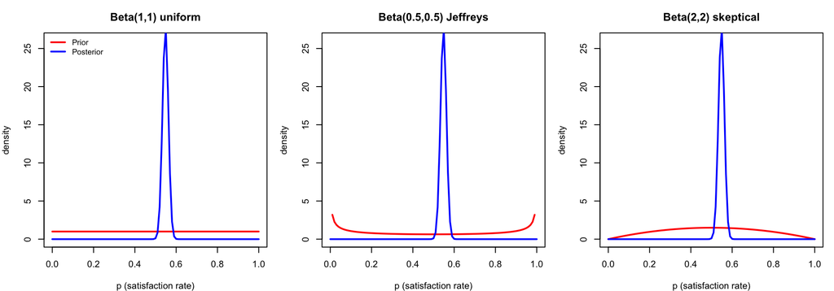

```r
par(mfrow = c(1, 3), mar = c(4, 4, 3, 1))

for (nm in names(priors)) {
  a0 <- priors[[nm]][1]; b0 <- priors[[nm]][2]
  a1 <- a0 + x; b1 <- b0 + n - x

  curve(dbeta(p, a0, b0), from = 0, to = 1, xname = "p",
        col = "red", lwd = 2, ylim = c(0, 26),
        xlab = "p (satisfaction rate)", ylab = "density", main = nm)
  curve(dbeta(p, a1, b1), from = 0, to = 1, xname = "p",
        add = TRUE, col = "blue", lwd = 2)

  if (nm == names(priors)[1]) {
    legend("topleft", c("Prior", "Posterior"), col = c("red", "blue"),
           lwd = 2, bty = "n", cex = 0.85)
  }
}
```

All three posteriors agree to at least three decimal places – with n ~= 1200, the data overwhelms any of these mild priors. This is the headline point of the sensitivity check: the specific prior chosen among these three does not materially affect the conclusion.

## 3. Subgroup estimates

The same closed-form update, refit independently within each level of cabin class, customer type, and travel type (each subgroup posterior is its own exact Beta – this is *not* a hierarchical/pooled model). We use the uniform Beta(1,1) prior throughout, since Section 2 already showed the prior choice barely matters at these sample sizes.

Note: only `satisfaction` and `cabin_class` were stratification variables in the Section 0 sampling design, so `customer_type` and `travel_type` subgroup sizes/splits reflect ordinary sampling variability rather than an exact match to their population shares.

```r
fit_group <- function(data, group_var, levels_order = NULL, a0 = 1, b0 = 1) {
  lv <- if (!is.null(levels_order)) levels_order else sort(unique(data[[group_var]]))
  do.call(rbind, lapply(lv, function(g) {
    sub <- data[data[[group_var]] == g, ]
    n_g <- nrow(sub)
    x_g <- sum(sub$satisfaction == "satisfied")
    a1 <- a0 + x_g; b1 <- b0 + n_g - x_g
    ci <- ci.beta(a1, b1)
    data.frame(
      group = g, n = n_g, x = x_g,
      post_mean = round(mean.beta(a1, b1), 4),
      ci_2.5    = round(ci[1], 4),
      ci_97.5   = round(ci[2], 4)
    )
  }))
}

cat("--- By cabin class ---\n")
```

```
## --- By cabin class ---
```

```r
fit_group(train, "cabin_class", levels_order = c("Eco", "Eco Plus", "Business"))
```

| group | n | x | post_mean | ci_2.5 | ci_97.5 |
| --- | --- | --- | --- | --- | --- |
| Eco | 538 | 212 | 0.3944 | 0.3536 | 0.4360 |
| Eco Plus | 86 | 37 | 0.4318 | 0.3306 | 0.5359 |
| Business | 573 | 407 | 0.7096 | 0.6718 | 0.7459 |

```r
cat("--- By customer type ---\n")
```

```
## --- By customer type ---
```

```r
fit_group(train, "customer_type")
```

| group | n | x | post_mean | ci_2.5 | ci_97.5 |
| --- | --- | --- | --- | --- | --- |
| disloyal Customer | 215 | 49 | 0.2304 | 0.1770 | 0.2886 |
| Loyal Customer | 982 | 607 | 0.6179 | 0.5873 | 0.6480 |

```r
cat("--- By travel type ---\n")
```

```
## --- By travel type ---
```

```r
fit_group(train, "travel_type")
```

| group | n | x | post_mean | ci_2.5 | ci_97.5 |
| --- | --- | --- | --- | --- | --- |
| Business travel | 839 | 485 | 0.5779 | 0.5444 | 0.6111 |
| Personal Travel | 358 | 171 | 0.4778 | 0.4264 | 0.5294 |

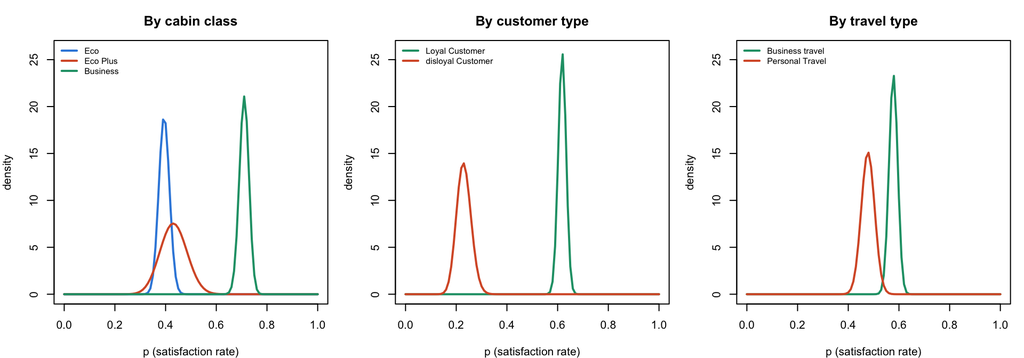

```r
par(mfrow = c(1, 3), mar = c(4, 4, 3, 1))

plot_group <- function(var, lv, cols, main) {
  plot(NA, xlim = c(0, 1), ylim = c(0, 26),
       xlab = "p (satisfaction rate)", ylab = "density", main = main)
  for (i in seq_along(lv)) {
    sub <- train[train[[var]] == lv[i], ]
    n_g <- nrow(sub); x_g <- sum(sub$satisfaction == "satisfied")
    curve(dbeta(p, 1 + x_g, 1 + n_g - x_g), from = 0, to = 1, xname = "p",
          add = TRUE, col = cols[i], lwd = 2)
  }
  legend("topleft", legend = lv, col = cols, lwd = 2, bty = "n", cex = 0.75)
}

plot_group("cabin_class",  c("Eco", "Eco Plus", "Business"),
           c("#378ADD", "#D85A30", "#1D9E75"), "By cabin class")
plot_group("customer_type", c("Loyal Customer", "disloyal Customer"),
           c("#1D9E75", "#D85A30"), "By customer type")
plot_group("travel_type",   c("Business travel", "Personal Travel"),
           c("#1D9E75", "#D85A30"), "By travel type")
```

## 4. Monte Carlo comparison between subgroups

For each pair, draw a large number of samples from each subgroup’s exact Beta posterior and estimate $P(p_A > p_B \mid \text{data})$ as the empirical proportion of paired draws where one exceeds the other. This needs no closed form and is the same Monte Carlo logic used throughout the rest of the course.

```r
set.seed(2026)
M <- 2e5

mc_compare <- function(data, group_var, g1, g2, a0 = 1, b0 = 1) {
  s1 <- data[data[[group_var]] == g1, ]
  s2 <- data[data[[group_var]] == g2, ]
  n1 <- nrow(s1); x1 <- sum(s1$satisfaction == "satisfied")
  n2 <- nrow(s2); x2 <- sum(s2$satisfaction == "satisfied")

  p1 <- rbeta(M, a0 + x1, b0 + n1 - x1)
  p2 <- rbeta(M, a0 + x2, b0 + n2 - x2)

  mean(p1 > p2)
}

results <- data.frame(
  comparison = c("P(Business > Eco)",
                 "P(Loyal Customer > disloyal Customer)",
                 "P(Business travel > Personal Travel)"),
  probability = c(
    mc_compare(train, "cabin_class", "Business", "Eco"),
    mc_compare(train, "customer_type", "Loyal Customer", "disloyal Customer"),
    mc_compare(train, "travel_type", "Business travel", "Personal Travel")
  )
)
results
```

| comparison | probability |
| --- | --- |
| P(Business > Eco) | 1.000000 |
| P(Loyal Customer > disloyal Customer) | 1.000000 |
| P(Business travel > Personal Travel) | 0.999385 |